# Anomaly_Detection

```python
import warnings
warnings.simplefilter("ignore")
import warnings
warnings.filterwarnings("ignore", category=DeprecationWarning)
import pandas as pd
import numpy as np
import sklearn as sk
import matplotlib.pyplot as plt
import random as rand
import itertools as it
from mpl_toolkits.mplot3d import Axes3D  # noqa: F401 unused import
from pandas import DataFrame, Series
import scipy
from scipy.cluster import hierarchy as hier
from scipy.cluster.hierarchy import dendrogram, linkage
from scipy.spatial.distance import pdist
from sklearn import preprocessing
from sklearn.preprocessing import StandardScaler, RobustScaler
from sklearn.decomposition import PCA
from sklearn.manifold import MDS
from sklearn.cluster import KMeans, AgglomerativeClustering, DBSCAN
from sklearn.neighbors import NearestNeighbors
from sklearn.metrics import accuracy_score, silhouette_score
from sklearn.model_selection import StratifiedKFold
```

```python
# your code goes here
data = pd.read_csv('data_subset_normalized_iqr_99_per.csv',header = 0)
data.index = list(data.iloc[:,0])
data = data.drop('Unnamed: 0',axis=1)
data.shape #rows, columns
```

```
(388, 321)
```

```python
def plot_2d(data,labels):
    plt.scatter(data[:, 0], data[:, 1], c=labels,marker='o')
    return plt
def plot_3d(data,labels):
    fig = plt.figure()
    ax = fig.add_subplot(111, projection='3d')
    plt.scatter(data[:, 0], data[:, 1],data[:,2], c=labels,marker='o')
    return plt
def dim_reduct_for_plot(data,key='pca',dim=2):
    if key == 'pca':
        pca = PCA(n_components = dim)
        ret = pca.fit_transform(data)
    elif key == 'tsne':
        model = tsne(n_components = dim,learning_rate =100)
        ret = model.fit_transform(data)
    elif key == 'MDS':
        mds = MDS(n_components=dim)
        ret = mds.fit_transform(data.iloc[:, :-1])

    return ret
```

## Isolation Forests Anomaly Detection

Isolation Forests do not suffer from the curse of dimensionality so we used it to detect anomalies on our subsetted data, which still has a large number of features. First we identified a set of outliers based every single feature in the data. The plots illustrate the positions of the outliers in 2-D and 3-D PCA space.

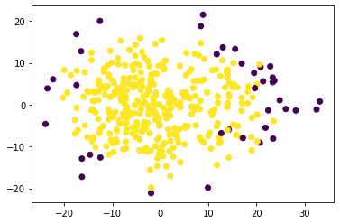

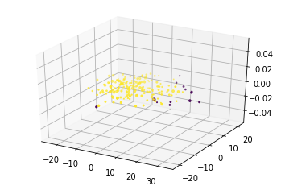

```python
# isolation forest documentation: https://scikit-learn.org/stable/modules/generated/sklearn.ensemble.IsolationForest.html

from sklearn.ensemble import IsolationForest as lf
lf = lf(max_features = len(data.columns))
pred=lf.fit_predict(data)

plot_2d(dim_reduct_for_plot(data),pred).show()
plot_3d(dim_reduct_for_plot(data, dim = 3),pred).show()
```

[output not shown]

[output cut: 587 more lines]

[output not shown]

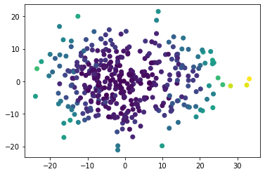

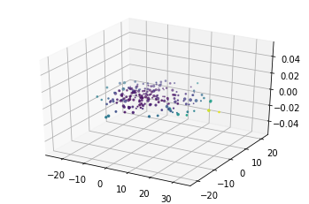

```python
from sklearn.ensemble import IsolationForest
data2 = data.copy()
data2["anomalies"] = 0
for i in data2.columns[:-1]:
    X = data2[i] #index column
    temp = (X.to_numpy()).reshape(-1, 1)
    lf = IsolationForest(bootstrap = False) #make lf object
    pred2 = lf.fit_predict(temp) #run lf on column
    pred2[pred2 == 1]=0
    pred2[pred2 == -1]=1
    data2["anomalies"] = data2["anomalies"] + pred2
plot_2d(dim_reduct_for_plot(data),data2["anomalies"]).show()
plot_3d(dim_reduct_for_plot(data, dim = 3),data2["anomalies"]).show()
```

```
Median number of anomalous features: 20.0
```

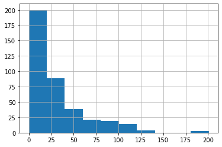

```python
#reference: https://towardsdatascience.com/isolation-forest-with-statistical-rules-4dd27dad2da9
print("Median number of anomalous features:", (data2['anomalies'].median()))
data2['anomalies'].hist()
```

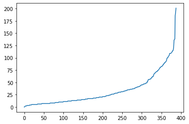

```python
plt.plot(sorted(data2['anomalies'].to_numpy()))
plt.show()
```

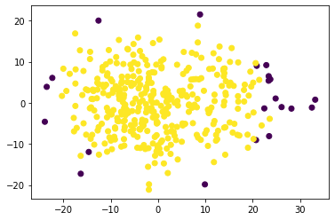

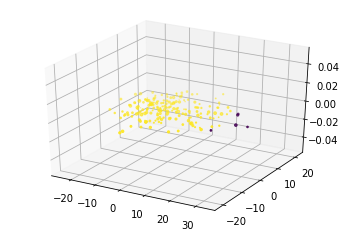

```python
pred2 = data2['anomalies']
pred2[pred2 <= 100]= 1
pred2[pred2 > 100]= -1
plot_2d(dim_reduct_for_plot(data),pred2).show()
plot_3d(dim_reduct_for_plot(data, dim = 3),pred2).show()
```

```python
anomaly_voting = pd.DataFrame({"if_all":pred, "if_single": pred2})
```

## Local Outlier Factor Anomaly Detection

Local Outlier Factor (LOF) anomaly detection uses density to find outliers. Not knowing which combination of LOF metric, K nearest neighbor value, and algrithem would work best, we used every combination of the sklearn options, as well as a range of KNN values. Some combinations were incompatible and therefore could not be used. We used the results of each to vote on which samples would be considered a LOF outlier. The 2-D and 3-D plots below show the results.

```
Error: 5 cosine ball_tree
Error: 5 cosine kd_tree
Error: 10 cosine ball_tree
Error: 10 cosine kd_tree
Error: 15 cosine ball_tree
Error: 15 cosine kd_tree
Error: 20 cosine ball_tree
Error: 20 cosine kd_tree
Error: 25 cosine ball_tree
Error: 25 cosine kd_tree
```

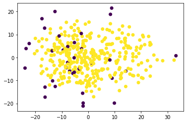

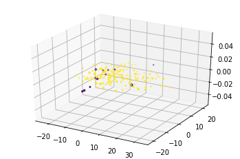

```python
# LOF documentation: https://scikit-learn.org/stable/modules/generated/sklearn.neighbors.LocalOutlierFactor.html
# Voting Reference: https://stackoverflow.com/questions/55749114/how-to-do-a-majority-voting-on-columns-in-pandas
from sklearn.neighbors import LocalOutlierFactor
temp = [0]*len(data)
LOFvoting = pd.DataFrame({"temp": temp})
for h in list(range(5,30,5)):
    for i in ["cityblock", "cosine", "euclidean", "l1", "l2", "manhattan", "minkowski"]:
        for j in ["auto", "ball_tree", "kd_tree", "brute"]:
            try:
                LOF = LocalOutlierFactor(algorithm = j, metric = i, n_neighbors = h)
                key = str(h) + i + j
                LOFvoting[key] = LOF.fit_predict(data)
            except:
                print("Error:", str(h), i, j)

anomaly_voting["LOF"] = (LOFvoting.mode(axis=1)[0]).to_numpy()
plot_2d(dim_reduct_for_plot(data),anomaly_voting["LOF"]).show()
plot_3d(dim_reduct_for_plot(data, dim = 3),anomaly_voting["LOF"]).show()
```

## Covariance Anomaly Detection

#### Elliptic Envelope

The Elliptic Envelope method fits a multivariate gaussian distribution to the dataset. It is subject to the curse of dimensionality and may not perform as well as isolation forests in finding outliers.

```
388
```

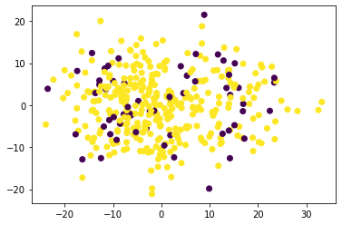

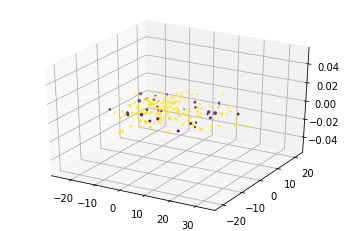

```python
from sklearn.covariance import EllipticEnvelope as EE
colors = np.array(['#377eb8', '#ff7f00'])
outliers_fraction = 0.25
X = data
#this will be your list of 16 plots
X_red = dim_reduct_for_plot(X,key='MDS',dim=3)
#apply EllipticEnvelope AD
#append resulting y_pred to y_pred_list
EE_ = EE(contamination = 0.15)
pred3 = EE_.fit_predict(X)
#plot(X_red,pred3,dim = 3,title = 'Elliptic Envelope')
print(len(pred3))
anomaly_voting["EE"] = pred3
plot_2d(dim_reduct_for_plot(data),pred3).show()
plot_3d(dim_reduct_for_plot(data, dim = 3),pred3).show()
```

## One-Class Support Vector Machine Anomaly Detection

A support vector machine (SVM) finds outliers by fitting a hyperplane to the data based on the number of expected outliers. Though we don't actually know how many outliers are in our data, this model does not suffer from the curse of dimensionality, which makes it useful to us. The plots illustrate the positions of the outliers in 2-D and 3-D PCA space.

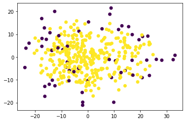

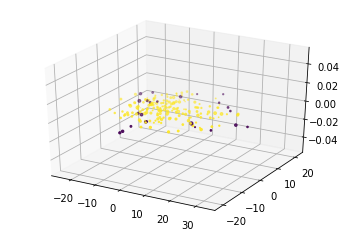

```python
from sklearn.svm import OneClassSVM as OCS
#apply OneClassSVM AD
#append resulting y_pred to y_pred_list
OCS_ = OCS(nu = 0.15, kernel = 'rbf')
pred4 = OCS_.fit_predict(X)
#plot(X_red,pred4,dim = 3,title = 'One Class SVM')
anomaly_voting["SVM"] = pred4
plot_2d(dim_reduct_for_plot(data),pred4).show()
plot_3d(dim_reduct_for_plot(data, dim = 3),pred4).show()
# plot_all(y_pred_list)
```

## Anomaly Detection and Elimination

Rather than using one method of anomaly detection we decided to employ multiple methods and use the results of each to vote on which samples were outliers and which were not. We did this because our dataset is small and we wanted to rigorously test to make sure a sample was an outlier before eliminating it. This also helped us to minimize the effect of each model's short comings with respect to our data (like suffering from the curse of dimensionality, ect.).

```python
consensus = anomaly_voting.mode(axis=1)[0]#voting
anoms = []
for i in range(len(consensus)):
    if consensus[i] == -1:
        anoms = anoms + [list(data.index)[i]]
print(len(anoms), "outliers detected.")
print("Sample IDS:", anoms)
dataSansAnom = data.drop(anoms)
print("New dataframe shape:", dataSansAnom.shape)
dataSansAnom.to_csv('data_subset_var_99_per_removed_anoms.csv')
```

[output not shown]